# pyMódulo 14

Curso IE0217 Estructuras abstractas y algoritmos para ingeniería - UCR

Profesor Freddy Rojas Ch.

02/14/2021

# Lenguaje Python 3 Módulo 14

Se continúa en el módulo 13 de Python con el estudio de ejemplos de aplicación de los métodos K-medias y Clusterización Jerárquica.

## Ejemplo #2

Se dispone de la siguiente tabla de la estimación del consumo promedio de proteínas, en gramos, por persona y por día, en Europa (datos del año 1981 en el archivo *ConsumoEuropa.csv*

La composición del archivo está detallada de esta forma:

1. El nombres de las filas corronde con el país européo.

2)Las columnas corresponden al consumo de los siguientes productos:

- Carne Animal
- Carne Cerdo
- Huevos
- Leche
- Carne Pescado
- Cereales
- Almidón
- Semillas
- Frutas

Se procede a establecer el conjunto de librerías que serán utilizadas.

#### Librerías requeridas

```python
import pandas as pd
import numpy as np
from   math import pi
import matplotlib.pyplot as plt
from   sklearn.cluster import KMeans

from scipy.cluster.hierarchy import dendrogram, ward, single, complete,average,linkage, fcluster
from scipy.spatial.distance import pdist
```

#### Funciones de opoyo

```python
def Plot():
    plt.show()
    plt.close()

def centroide(num_cluster, datos, clusters):
  ind = clusters == num_cluster
  return(pd.DataFrame(datos[ind].mean()).T)
```

#### Contenido del archivo

Para observar el contenido del archivo se usa el siguiente código:

```python
datos = pd.read_csv('../Datos/ConsumoEuropa.csv',delimiter=';',decimal=',',index_col =0)
datos=datos.dropna()
print(datos)
```

```
##                 CarneAnimal  CarneCerdo  Huevos  ...  Almidon  Semillas  Frutas
## Albania                10.1         1.4     0.5  ...      0.6       5.5     1.7
## Austria                 8.9        14.0     4.3  ...      3.6       1.3     4.3
## Belgica                13.5         9.3     4.1  ...      5.7       2.1     4.0
## Bulgaria                7.8         6.0     1.6  ...      1.1       3.7     4.2
## Checoslovaquia          9.7        11.4     2.8  ...      5.0       1.1     4.0
## Dinamarca              10.6        10.8     3.7  ...      4.8       0.7     2.4
## Alemania Or.            8.4        11.6     3.7  ...      6.5       0.8     3.6
## Finlandia               9.5         4.9     2.7  ...      5.1       1.0     1.4
## Francia                18.0         9.9     3.3  ...      4.8       2.4     6.5
## Grecia                 10.2         3.0     2.8  ...      2.2       7.8     6.5
## Hungria                 5.3        12.4     2.9  ...      4.0       5.4     4.2
## Irlanda                13.9        10.0     4.7  ...      6.2       1.6     2.9
## Italia                  9.0         5.1     2.9  ...      2.1       4.3     6.7
## Holanda                 9.5        13.6     3.6  ...      4.2       1.8     3.7
## Noruega                 9.4         4.7     2.7  ...      4.6       1.6     2.7
## Polonia                 6.9        10.2     2.7  ...      5.9       2.0     6.6
## Portugal                6.2         3.7     1.1  ...      5.9       4.7     7.9
## Rumania                 6.2         6.3     1.5  ...      3.1       5.3     2.8
## Espana                  7.1         3.4     3.1  ...      5.7       5.9     7.2
## Suecia                  9.9         7.8     3.5  ...      3.7       1.4     2.0
## Suiza                  13.1        10.1     3.1  ...      2.8       2.4     4.9
## Reino Unido            17.4         5.7     4.7  ...      4.7       3.4     3.3
## URSS                    9.3         4.6     2.1  ...      6.4       3.4     2.9
## Alemania Occ.          11.4        12.5     4.1  ...      5.2       1.5     3.8
## Yugoslavia              4.4         5.0     1.2  ...      3.0       5.7     3.2
##
## [25 rows x 9 columns]
```

#### Análisis del contenido y estructuración de variables.

```python
print("Análsis de archivo")
```

```
## Análsis de archivo
```

```python
print("+++++++++++++++++++++")
```

```
## +++++++++++++++++++++
```

```python
print(datos.dtypes)

#Nombres de variables
```

```
## CarneAnimal     float64
## CarneCerdo      float64
## Huevos          float64
## Leche           float64
## CarnePescado    float64
## Cereales        float64
## Almidon         float64
## Semillas        float64
## Frutas          float64
## dtype: object
```

```python
NombreTodasVar=datos.columns.values.tolist()
print("Nombre de todas las variables \n%s" % NombreTodasVar)
```

```
## Nombre de todas las variables
## ['CarneAnimal', 'CarneCerdo', 'Huevos', 'Leche', 'CarnePescado', 'Cereales', 'Almidon', 'Semillas', 'Frutas']
```

```python
df_numericas = datos.select_dtypes(include=['float64','int64'])
NombresNumericas=df_numericas.columns.values.tolist()
print("Nombre de variables numéricas \n%s" % NombresNumericas)
```

```
## Nombre de variables numéricas
## ['CarneAnimal', 'CarneCerdo', 'Huevos', 'Leche', 'CarnePescado', 'Cereales', 'Almidon', 'Semillas', 'Frutas']
```

### Clusterización Jerárquica

Se construyen las instancias para: salto mínimo, salto máximo, promedio y "Ward’’. Luego se procede a generar los gráficos de los dendogramas.

#### Dendogramas

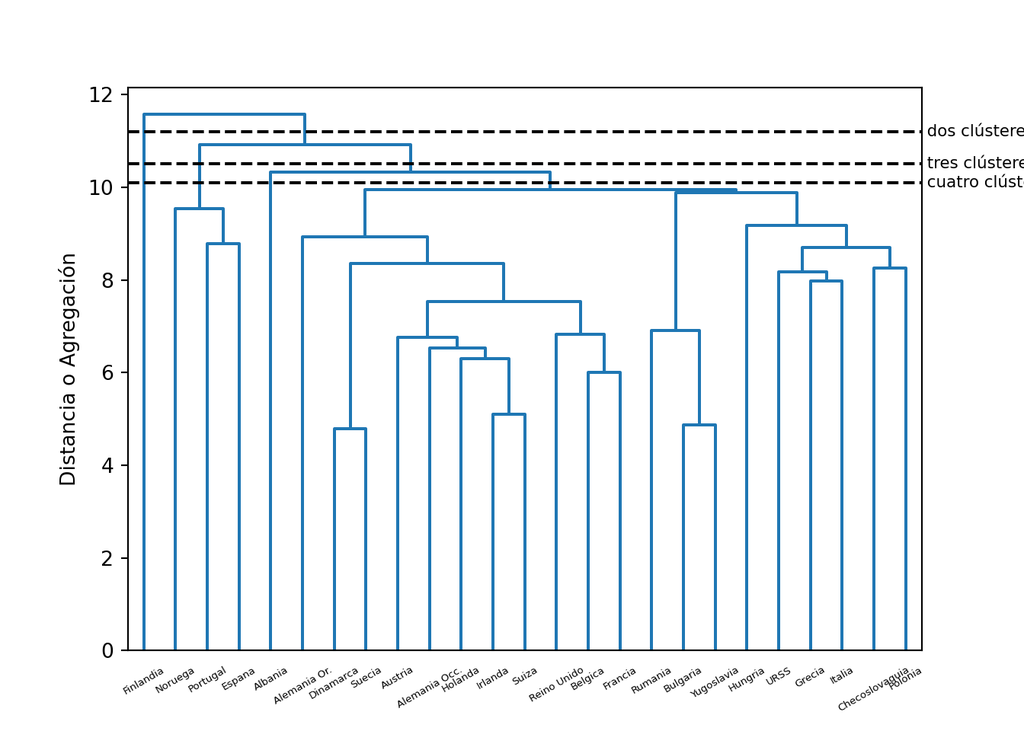

```python
### CLUSTERING JERARQUICO
single_res = single(datos)          #Salto mínimo
complete_res = complete(datos)      #Salto Máximo
average_res = average(datos)        #Promedio
ward_res = ward(datos)              #Ward

## Dendogramas
null=dendrogram(single_res,color_threshold=3,labels= datos.index.tolist(),leaf_rotation=30,leaf_font_size=5)
ax = plt.gca()
limites = ax.get_xbound()

ax.plot(limites, [11.2, 11.2], '--', c='k')
ax.text(limites[1], 11.2, ' dos clústeres', va='center', fontdict={'size': 8})

ax.plot(limites, [10.5, 10.5], '--', c='k')
ax.text(limites[1], 10.5, ' tres clústeres', va='center', fontdict={'size': 8})

ax.plot(limites, [10.1, 10.1], '--', c='k')
ax.text(limites[1], 10.1, ' cuatro clústeres', va='center', fontdict={'size': 8})

plt.ylabel("Distancia o Agregación")
Plot()
```

En el primer gráfico se observa claramente para una partición de dos ramas la agrupación: Finlandia y el resto de Europa.

Para una partición de tres clusters se objservan los grupos Finlandia, luego Noruega, Portugal y España y el resto de Europa.

Para una partición de cuatro grupos se agrega Albania de los grupos anteriores.

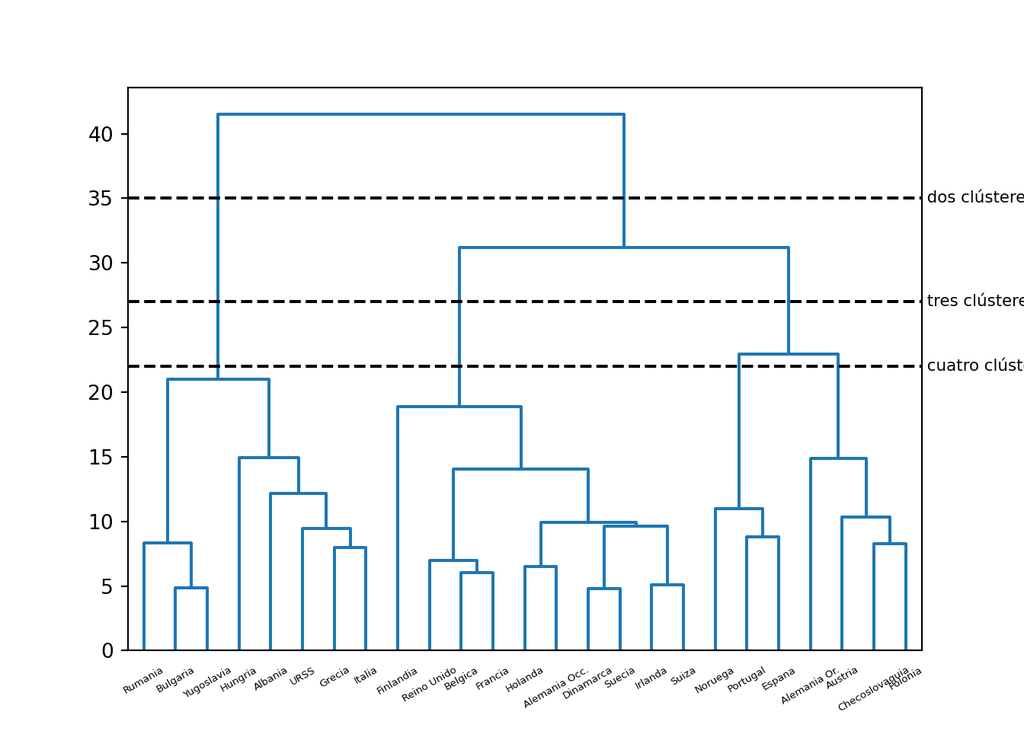

```python
null=dendrogram(complete_res,color_threshold=3,labels= datos.index.tolist(),leaf_rotation=30,leaf_font_size=5)
ax = plt.gca()
limites = ax.get_xbound()

ax.plot(limites, [35, 35], '--', c='k')
ax.text(limites[1], 35, ' dos clústeres', va='center', fontdict={'size': 8})

ax.plot(limites, [27,27], '--', c='k')
ax.text(limites[1], 27, ' tres clústeres', va='center', fontdict={'size': 8})

ax.plot(limites, [22, 22], '--', c='k')
ax.text(limites[1], 22, ' cuatro clústeres', va='center', fontdict={'size': 8})
Plot()
```

En el segundo caso, para salto máximo, los grupos se ordenan diferente. Para dos ramas se separan: Ruamanía, Bulgaria, Yugoslavia, Hungría, Albania, Rusia, Grecia e Italia, países de centro hacia el sur de Europa. El otro grupo lo conforma el resto de Europa.

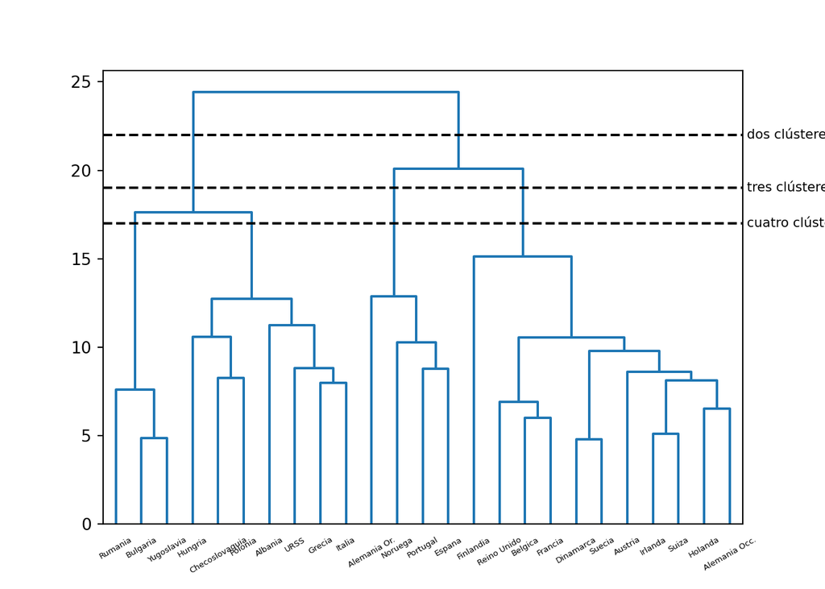

```python
null=dendrogram(average_res,color_threshold=3,labels= datos.index.tolist(),leaf_rotation=30,leaf_font_size=5)
ax = plt.gca()
limites = ax.get_xbound()

ax.plot(limites, [22, 22], '--', c='k')
ax.text(limites[1], 22, ' dos clústeres', va='center', fontdict={'size': 8})

ax.plot(limites, [19,19], '--', c='k')
ax.text(limites[1], 19, ' tres clústeres', va='center', fontdict={'size': 8})

ax.plot(limites, [17, 17], '--', c='k')
ax.text(limites[1], 17, ' cuatro clústeres', va='center', fontdict={'size': 8})
Plot()
```

En el tercer caso para salto promedio, los grupos se ordenan bastante más parecidos al caso del salto máximo (caso 2)

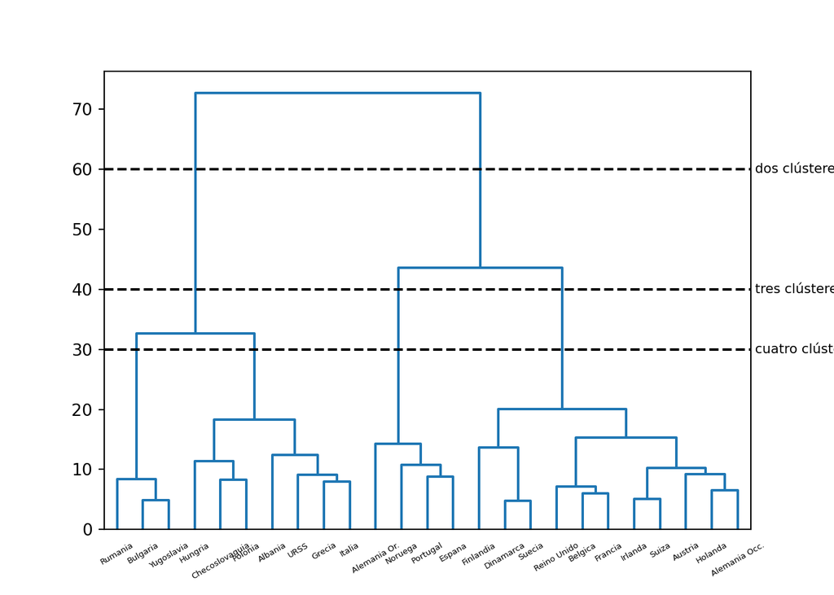

```python
null=dendrogram(ward_res,color_threshold=3,labels= datos.index.tolist(),leaf_rotation=30,leaf_font_size=5)
ax = plt.gca()
limites = ax.get_xbound()

ax.plot(limites, [60, 60], '--', c='k')
ax.text(limites[1], 60, ' dos clústeres', va='center', fontdict={'size': 8})

ax.plot(limites, [40,40], '--', c='k')
ax.text(limites[1], 40, ' tres clústeres', va='center', fontdict={'size': 8})

ax.plot(limites, [30, 30], '--', c='k')
ax.text(limites[1], 30, ' cuatro clústeres', va='center', fontdict={'size': 8})
Plot()
```

Finalmente para el cuarto caso con salto de Ward, los grupos se ordenan de nuevo de una forma muy parecidos al caso del salto máximo(caso 2).

#### Gráficos de barras

Se ejecuta el siguiente código para obtener los gráficos de barras de los cluster usando agregación de Ward.

```python
#BAR plot
grupos = fcluster(linkage(pdist(datos), method='ward'),3,criterion='maxclust')
print(grupos)
```

```
## [1 3 3 1 1 3 2 3 3 1 1 3 1 3 2 1 2 1 2 3 3 3 1 3 1]
```

```python
centros = np.array(   pd.concat([centroide(1,datos,grupos),
                                 centroide(2,datos,grupos),
                                 centroide(3,datos,grupos) ])  )
print(centros)
```

```
## [[ 7.89        6.54        2.1        12.72        2.06       43.71
##    3.34        4.42        4.28      ]
##  [ 7.775       5.85        2.65        6.975       9.075      25.95
##    5.675       3.25        5.35      ]
##  [12.33636364  9.87272727  3.8        22.97272727  4.56363636 24.11818182
##    4.61818182  1.78181818  3.56363636]]
```

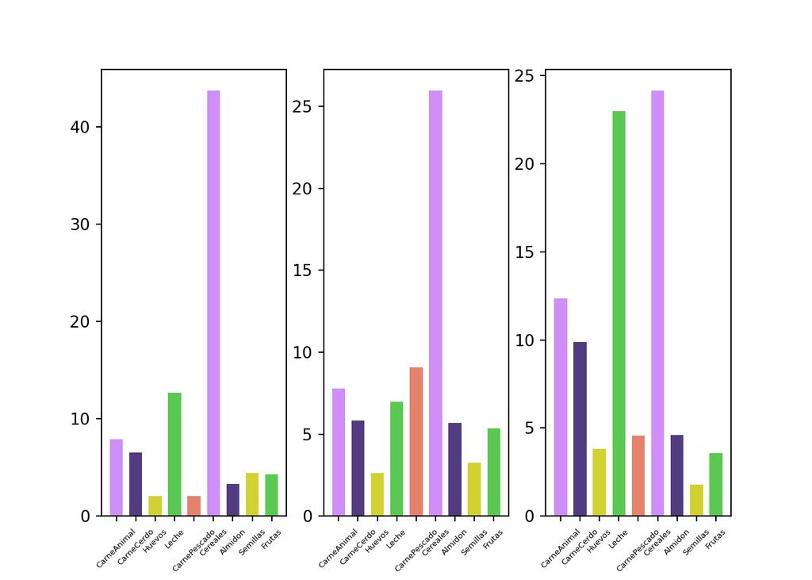

```python
colores_1 = ['#CF8EF8', '#523C81', '#D2D132', '#59C951', '#E5826C']

# Plotea Centro 1
plt.subplot(1, 3, 1)
y  = centros[:1, :].tolist()[0]
null=plt.bar(range(len(y)), y, 1/1.5, color=colores_1)
null=plt.xticks(range(datos.shape[1]), datos.columns,rotation=45,fontsize=5)

# Plotea Centro 2
plt.subplot(1, 3, 2)
y= centros[1:2, :].tolist()[0]
null=plt.bar(range(len(y)), y, 1/1.5, color=colores_1)
null=plt.xticks(range(datos.shape[1]), datos.columns,rotation=45,fontsize=5)

# Plotea Centro 3
plt.subplot(1, 3, 3)
y= centros[2:3, :].tolist()[0]
null=plt.bar(range(len(y)), y, 1/1.5, color=colores_1)
null=plt.xticks(range(datos.shape[1]), datos.columns,rotation=45,fontsize=5)
Plot()
```

En los gráficos resultantes se etablecen los grupos de productos de consumo que corresponden con los grupos de países que fueron clasificados anteriormente en el dendograma de agregación de ward.

#### Gráfico de radar

Ahora se procede con el siguiente código a generar los gráficos de radar

```python
#Radar plot
centros_trans = centros.T
df = pd.DataFrame()
for i in range(datos.shape[1]):
    df = pd.concat([df,pd.DataFrame({datos.columns[i]:centros_trans[i,:].tolist()})],
                   axis = 1)
df =  pd.concat([df,pd.DataFrame(  {'grupo': ['Cluster-1','Cluster-2','Cluster-3'] } )],
                axis = 1)
print(df)
```

```
##    CarneAnimal  CarneCerdo  Huevos  ...  Semillas    Frutas      grupo
## 0     7.890000    6.540000    2.10  ...  4.420000  4.280000  Cluster-1
## 1     7.775000    5.850000    2.65  ...  3.250000  5.350000  Cluster-2
## 2    12.336364    9.872727    3.80  ...  1.781818  3.563636  Cluster-3
##
## [3 rows x 10 columns]
```

```python
maximo=df.max(axis=1).max()
variables=list(df)[0:datos.shape[1]]
print(variables)
```

```
## ['CarneAnimal', 'CarneCerdo', 'Huevos', 'Leche', 'CarnePescado', 'Cereales', 'Almidon', 'Semillas', 'Frutas']
```

```python
N = len(variables)
angulos = [n / float(N) * 2 * pi for n in range(N)]
angulos+= angulos[:1]

#Generación de Radar
ax = plt.subplot(111, polar=True)
ax.set_theta_offset(pi / 2)
ax.set_theta_direction(-1)
null=plt.xticks(angulos[:-1], variables)
ax.set_rlabel_position(0)
lista=np.arange(1,11)*int(maximo/10)
lista_p=lista.astype(str)
null=plt.yticks(lista, lista_p, color="grey", size=7)
plt.ylim(0,maximo)

#Cluster 1
```

```
## (0.0, 43.71)
```

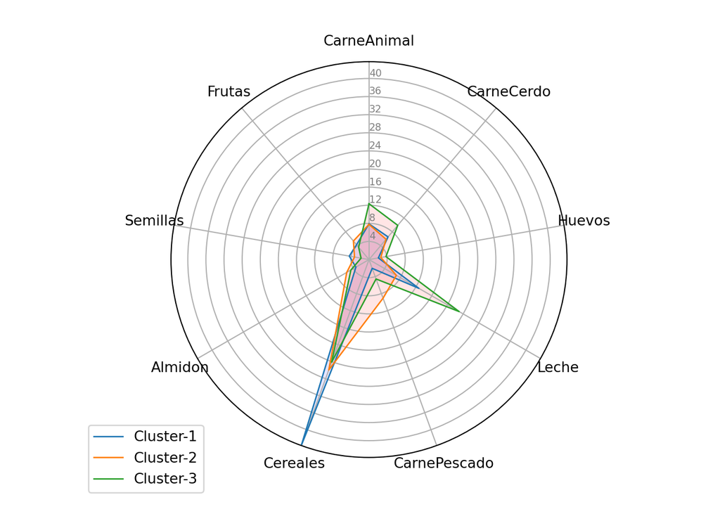

```python
valores=df.loc[0].drop('grupo').values.flatten().tolist()
valores += valores[:1]
ax.plot(angulos, valores, linewidth=1, linestyle='solid', label="Cluster-1")
ax.fill(angulos, valores, 'b', alpha=0.1)

#Cluster 2
valores=df.loc[1].drop('grupo').values.flatten().tolist()
valores += valores[:1]
ax.plot(angulos, valores, linewidth=1, linestyle='solid', label="Cluster-2")
ax.fill(angulos, valores, 'r', alpha=0.1)

#Cluster 3
valores=df.loc[2].drop('grupo').values.flatten().tolist()
valores += valores[:1]
ax.plot(angulos, valores, linewidth=1, linestyle='solid', label="Cluster-3")
ax.fill(angulos, valores, 'r', alpha=0.1)

plt.legend(loc='upper right', bbox_to_anchor=(0.1, 0.1))

Plot()
```

El diagrama de radar da una mejor percepción de los descrito en la sección anterior.

### Estudio K medias

El código para realizar el análisis con K medias es el siguiente:

```python
#K medias
kmedias = KMeans(n_clusters=3)
kmedias.fit(datos)
```

```
## KMeans(n_clusters=3)
```

```python
print(kmedias.predict(datos))
```

```
## [0 1 1 0 2 1 2 1 1 0 0 1 0 1 2 0 2 0 2 1 1 1 0 1 0]
```

```python
centros = np.array(kmedias.cluster_centers_)
print(centros)
```

```
## [[ 7.68888889  6.          2.02222222 12.74444444  2.06666667 44.75555556
##    3.15555556  4.78888889  4.31111111]
##  [12.33636364  9.87272727  3.8        22.97272727  4.56363636 24.11818182
##    4.61818182  1.78181818  3.56363636]
##  [ 8.16        6.96        2.68        8.08        7.66       27.62
##    5.54        2.82        5.08      ]]
```

#### Gráfico de barras K/medias para Consumo en Europa

Se procede a producir el gráfico de barras por clúster.

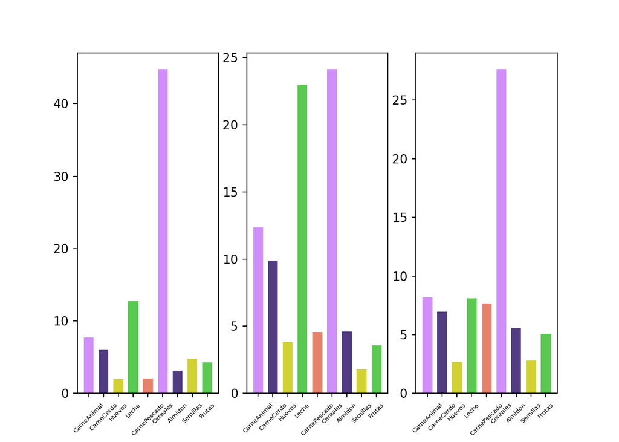

```python
#Bar plot
colores_1 = ['#CF8EF8', '#523C81', '#D2D132', '#59C951', '#E5826C']
#plt.figure(1,figsize=(25,15))

# Plotea Centro 1
plt.subplot(1, 3, 1)
y  = centros[:1, :].tolist()[0]
null=plt.bar(range(len(y)), y, 1/1.5, color=colores_1)
null=plt.xticks(range(datos.shape[1]), datos.columns,rotation=45,fontsize=5)

# Plotea Centro 2
plt.subplot(1, 3, 2)
y= centros[1:2, :].tolist()[0]
null=plt.bar(range(len(y)), y, 1/1.5, color=colores_1)
null=plt.xticks(range(datos.shape[1]), datos.columns,rotation=45,fontsize=5)

# Plotea Centro 3
plt.subplot(1, 3, 3)
y= centros[2:3, :].tolist()[0]
null=plt.bar(range(len(y)), y, 1/1.5, color=colores_1)
null=plt.xticks(range(datos.shape[1]), datos.columns,rotation=45,fontsize=5)

Plot()
```

#### Gráficos radar para análisis con k medias

El gráfico de radar se confecciona con este código:

```python
#Radar plot
centros_trans = centros.T
df = pd.DataFrame()
for i in range(datos.shape[1]):
    df = pd.concat([df,pd.DataFrame({datos.columns[i]:centros_trans[i,:].tolist()})],
                   axis = 1)
df =  pd.concat([df,pd.DataFrame(  {'grupo': ['Cluster-1','Cluster-2','Cluster-3'] } )],
                axis = 1)
print(df)
```

```
##    CarneAnimal  CarneCerdo    Huevos  ...  Semillas    Frutas      grupo
## 0     7.688889    6.000000  2.022222  ...  4.788889  4.311111  Cluster-1
## 1    12.336364    9.872727  3.800000  ...  1.781818  3.563636  Cluster-2
## 2     8.160000    6.960000  2.680000  ...  2.820000  5.080000  Cluster-3
##
## [3 rows x 10 columns]
```

```python
maximo=df.max(axis=1).max()
variables=list(df)[0:datos.shape[1]]
print(variables)
```

```
## ['CarneAnimal', 'CarneCerdo', 'Huevos', 'Leche', 'CarnePescado', 'Cereales', 'Almidon', 'Semillas', 'Frutas']
```

```python
N = len(variables)
angulos = [n / float(N) * 2 * pi for n in range(N)]
angulos+= angulos[:1]

#Generación de Radar
ax = plt.subplot(111, polar=True)
ax.set_theta_offset(pi / 2)
ax.set_theta_direction(-1)
null=plt.xticks(angulos[:-1], variables)
ax.set_rlabel_position(0)
lista=np.arange(1,11)*int(maximo/10)
lista_p=lista.astype(str)
null=plt.yticks(lista, lista_p, color="grey", size=7)
plt.ylim(0,maximo)

#Cluster 1
```

```
## (0.0, 44.75555555555555)
```

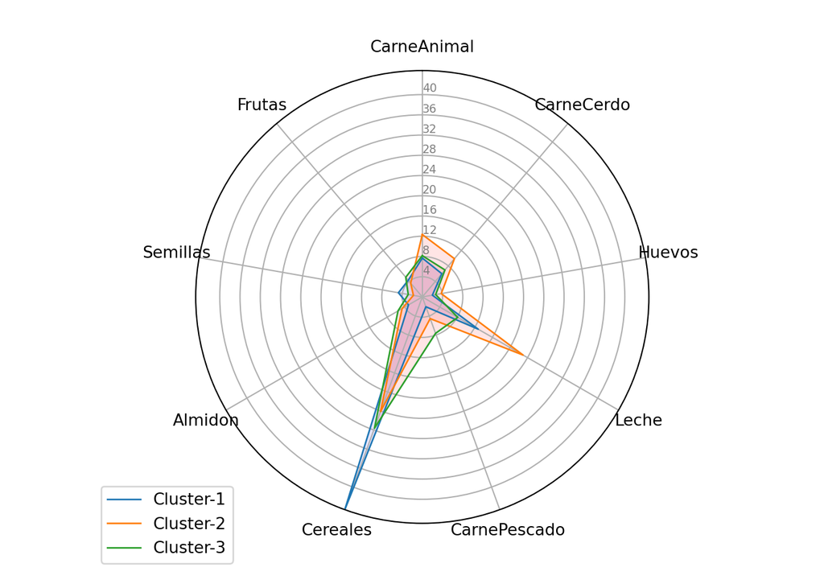

```python
valores=df.loc[0].drop('grupo').values.flatten().tolist()
valores += valores[:1]
ax.plot(angulos, valores, linewidth=1, linestyle='solid', label="Cluster-1")
ax.fill(angulos, valores, 'b', alpha=0.1)

#Cluster 2
valores=df.loc[1].drop('grupo').values.flatten().tolist()
valores += valores[:1]
ax.plot(angulos, valores, linewidth=1, linestyle='solid', label="Cluster-2")
ax.fill(angulos, valores, 'r', alpha=0.1)

#Cluster 3
valores=df.loc[2].drop('grupo').values.flatten().tolist()
valores += valores[:1]
ax.plot(angulos, valores, linewidth=1, linestyle='solid', label="Cluster-3")
ax.fill(angulos, valores, 'r', alpha=0.1)

plt.legend(loc='upper right', bbox_to_anchor=(0.1, 0.1))

Plot()
```

#### Codo de Jambú

El gráfico para el codo de Jambú se muetra en el siguiente segmento de código:

```python
#Codo de Jambú
print("Codo de Jambú inercia interclases")
```

```
## Codo de Jambú inercia interclases
```

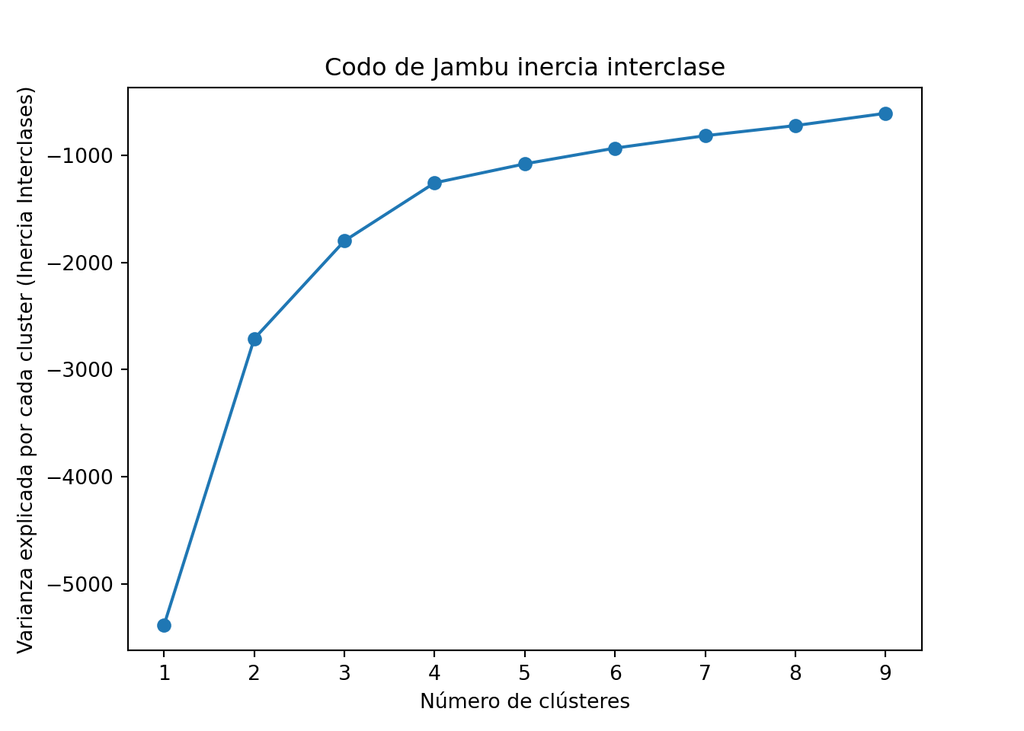

```python
Nc = range(1, 10)
kmediasList = [KMeans(n_clusters=i) for i in Nc]
varianza = [kmediasList[i].fit(datos).score(datos)
            for i in range(len(kmediasList))]
plt.plot(Nc,varianza,'o-')
plt.xlabel('Número de clústeres')
plt.ylabel('Varianza explicada por cada cluster (Inercia Interclases)')
plt.title('Codo de Jambu inercia interclase')
Plot()
```

```python
print("Codo de Jambú inercia intraclases")
```

```
## Codo de Jambú inercia intraclases
```

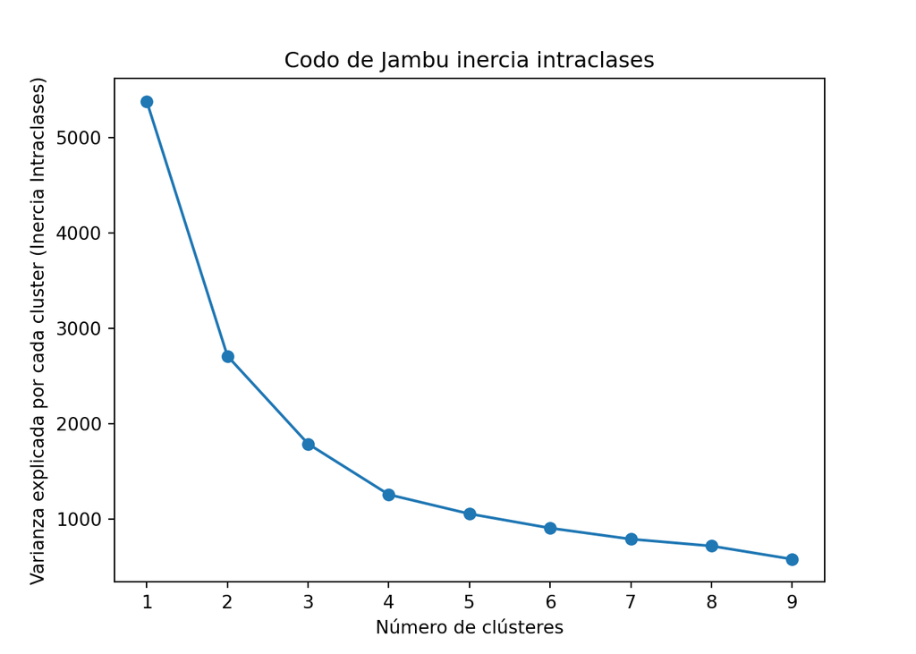

```python
Nc = range(1, 10)
kmediasList = [KMeans(n_clusters=i) for i in Nc]
varianza = [kmediasList[i].fit(datos).inertia_
            for i in range(len(kmediasList))]
plt.plot(Nc,varianza,'o-')
plt.xlabel('Número de clústeres')
plt.ylabel('Varianza explicada por cada cluster (Inercia Intraclases)')
plt.title('Codo de Jambu inercia intraclases')
Plot()
```